# HW 6 Contrastive learning

## 2.8 Plot loss history

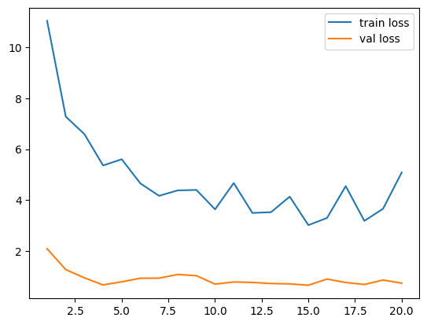

```python
import matplotlib.pyplot as plt

plt.plot(np.arange(1, len(train_losses) + 1), train_losses, label="train loss")
plt.plot(np.arange(1, len(val_losses) + 1), val_losses, label="val loss")
plt.legend()
plt.show()
```

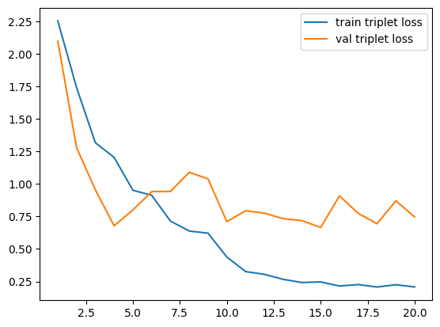

```python
import matplotlib.pyplot as plt

plt.plot(
    np.arange(1, len(train_losses) + 1),
    train_triplet_losses,
    label="train triplet loss",
)
plt.plot(
    np.arange(1, len(val_losses) + 1), val_triplet_losses, label="val triplet loss"
)
plt.legend()
plt.show()
```

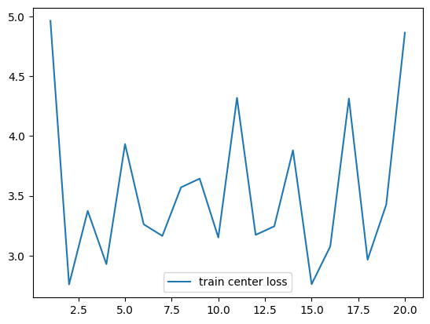

```python
import matplotlib.pyplot as plt

plt.plot(
    np.arange(1, len(train_losses) + 1), train_center_losses, label="train center loss"
)
plt.legend()
plt.show()
```

## 2.9 (TODO) Plot t-SNE

This section is similar to section 1.8 but the network is instead optimized using a combined triplet, center, and cross-entropy loss.

**Instructions**

TODO 12: Extract the feature vectors of the test set and store them as

`embeddings`: torch.FloatTensor = feature vectors of all images in the test set

`identities`: list or torch.Tensor or np.array = identities of all images in the test set

**Hint**  
Use `FaceDataset` that is imported at `Common Dataset` section

**WARNING!!** Don't forget load its best weights and change to eval mode first

```python
test_batch_size = 32

# TODO 12: Extract the feature vectors of the test set and store them as
# `embeddings`: torch.FloatTensor = feature vectors of all images in the test set
# `identities`: list or torch.Tensor or np.array = identities of all images in the test set
# Hint      => Use `FaceDataset` that is imported at `Common Dataset` section
# WARNING!! => Don't forget load its best weights and change to eval mode first
embeddings = []
identities = []
test_dataset = FaceDataset(root_dir="large_prepared_data/test", transform=val_transform)
test_loader = DataLoader(test_dataset, batch_size=test_batch_size)
triplet_model.load_state_dict(torch.load(best_weights_path, map_location=device))
triplet_model.eval()

with torch.no_grad():
    for transformed_img, identity, _ in tqdm(test_loader):
        transformed_img = transformed_img.to(device)
        feat = triplet_model.extract_feature(transformed_img)
        embeddings.append(feat.cpu())
        if torch.is_tensor(identity):
            identities.append(identity.cpu())
        else:
            identities.extend(identity)
embeddings = torch.cat(embeddings)
if torch.is_tensor(identities[0]):
    identities = torch.cat(identities)
else:
    identities = np.array(identities)
```

```python
import time
from sklearn.manifold import TSNE

time_start = time.time()
tsne = TSNE(n_components=2, verbose=1, perplexity=30, max_iter=3000)
tsne_result = tsne.fit_transform(embeddings)
print("t-SNE done! Time elapsed: {} seconds".format(time.time() - time_start))
```

```
[t-SNE] Computing 91 nearest neighbors...
[t-SNE] Indexed 301 samples in 0.000s...
[t-SNE] Computed neighbors for 301 samples in 0.077s...
[t-SNE] Computed conditional probabilities for sample 301 / 301
[t-SNE] Mean sigma: 9.891579
[t-SNE] KL divergence after 250 iterations with early exaggeration: 56.432346
[t-SNE] KL divergence after 2650 iterations: 0.810642
t-SNE done! Time elapsed: 0.9990594387054443 seconds
```

```python
import plotly.express as px

label = []
idx = 0
id2label = dict()
for identity in identities:
    identity = int(identity)
    if identity not in id2label:
        id2label[identity] = idx
        idx += 1
    label.append(id2label[identity])

df_subset = pd.DataFrame({"label": label})

df_subset["tsne-2d-one"] = tsne_result[:, 0]
df_subset["tsne-2d-two"] = tsne_result[:, 1]

fig = px.scatter(
    df_subset, x="tsne-2d-one", y="tsne-2d-two", color="label", height=1000, width=1000
)
fig.update_layout(margin=dict(l=0, r=0, b=0, t=0))
fig.show()
```

[output not shown]

```python
import time
from sklearn.manifold import TSNE

time_start = time.time()
tsne = TSNE(n_components=3, verbose=1, perplexity=30, max_iter=3000)
tsne_result = tsne.fit_transform(embeddings)
print("t-SNE done! Time elapsed: {} seconds".format(time.time() - time_start))
```

```
[t-SNE] Computing 91 nearest neighbors...
[t-SNE] Indexed 301 samples in 0.000s...
[t-SNE] Computed neighbors for 301 samples in 0.008s...
[t-SNE] Computed conditional probabilities for sample 301 / 301
[t-SNE] Mean sigma: 9.891579
[t-SNE] KL divergence after 250 iterations with early exaggeration: 57.473373
[t-SNE] KL divergence after 2100 iterations: 0.759663
t-SNE done! Time elapsed: 1.1960453987121582 seconds
```

```python
import plotly.express as px

label = []
idx = 0
id2label = dict()
for identity in identities:
    identity = int(identity)
    if identity not in id2label:
        id2label[identity] = idx
        idx += 1
    label.append(id2label[identity])

df_subset = pd.DataFrame({"label": label})

df_subset["tsne-3d-one"] = tsne_result[:, 0]
df_subset["tsne-3d-two"] = tsne_result[:, 1]
df_subset["tsne-3d-three"] = tsne_result[:, 2]

fig = px.scatter_3d(
    df_subset, x="tsne-3d-one", y="tsne-3d-two", z="tsne-3d-three", color="label"
)
fig.update_layout(margin=dict(l=0, r=0, b=0, t=0))
fig.show()
```

[output not shown]

## 2.10 (TODO) Embedding comparison

TODO 13: Compare the visualization of the triplet network to the siamese network. Which one is better and why?

Answer here: triplet network is better. From the visualization we can clearly see that the same identity start to clustering with each other.

## (Optional) Try other tricks to get higher quality of face embeddings such as

1. GeM Pooling (ref: https://amaarora.github.io/2020/08/30/gempool.html)
2. Arcface (ref: https://arxiv.org/abs/1801.07698)
3. Hard negative mining (ref: https://omoindrot.github.io/triplet-loss)
4. Semi-hard mining

and plot t-SNE to compare with vanilla triplet loss

# Part 3 : Face recognition using InfoNCE loss

In contrast to the contrastive and triplet loss that only pulls an image pair of the same identity to come closer and push a different one away, some alternative approaches, such as the N-pair (ref: [paper](https://papers.nips.cc/paper_files/paper/2016/file/6b180037abbebea991d8b1232f8a8ca9-Paper.pdf)) and InfoNCE (ref: [paper](https://arxiv.org/pdf/1807.03748v2.pdf)) loss, take multiple positive images or/and multiple negative images into consideration. In this part, you are going to implement a variant of the InfoNCE loss where multiple positive and negative images are simutaneously utilized during the learning process. Moreover, the loss function implemented in this homework also adopts temperature scaling, a concept widely applied in many state-of-the-art self-supervised learning such as SimCLR (ref: [paper](https://arxiv.org/abs/2002.05709)), instead of the margin used in triplet and vanilla contrastive loss.

## 3.1 (TODO) Dataset and DataLoader

In this section, you are going to implement a dataloader for the combined loss. The dataloader should return the tuple `(anchor_img, pos_imgs, neg_imgs, anchor_label, pos_labels, neg_labels)`.

- The positive image must have the same identity as the anchor image.
- The negative image must have a different identity from the anchor image.

this dataloader will sample both multiple positive images and multiple negative images per anchor image

```python
import copy


class InfoNCEDataset(Dataset):
    def __init__(self, root_dir, transform=None, num_pos=4, num_neg=8):
        np.random.seed(123)
        random.seed(123)
        self.root_dir = root_dir
        self.transform = transform
        self.num_pos = num_pos
        self.num_neg = num_neg

        label_df = pd.read_csv(f"{root_dir}/label_df.csv")
        label_df = (
            label_df.groupby("identity")["filename"]
            .apply(list)
            .reset_index()
            .rename({"filename": "filenames"}, axis=1)
        )
        self.images = []
        self.labels = []
        self.label2indices = dict()
        self.load_images_to_memory_(label_df)

    def load_images_to_memory_(self, label_df):
        # load images and labels into memory
        # We have to relabel from identities to 0,1,2,...,num_classes-1
        # Relevant variables
        # 1. `self.images` = PIL images  (Also convert it to RGB)
        # 2. `self.label2indices` = the dictionary storing a label as a key and the indices of images as value
        # 3. `self.labels` = labels of images (relabeled)
        # Note: the index of images is from iterating over label_df
        self.images = []
        self.label2indices = defaultdict(list)
        self.labels = []
        img_idx = 0
        label_idx = 0
        identity2label = dict()
        for idx in tqdm(range(len(label_df))):
            row = label_df.iloc[idx]
            identity, filenames = row["identity"], row["filenames"]

            if identity not in identity2label:
                identity2label[identity] = label_idx
                label_idx += 1

            label = identity2label[identity]

            for filename in filenames:
                self.images.append(
                    Image.open(f"{self.root_dir}/{filename}").convert("RGB")
                )
                self.labels.append(label)
                self.label2indices[label].append(img_idx)
                img_idx += 1

    def __len__(self):
        return len(self.images)

    def __getitem__(self, idx):
        """
        sample images labels
        [args]
        - idx is an index of an image

        [intermediate]
        - anchor image is the image according to idx
        - positive images (dim: [num_pos, num_feat]) is a list of image that has the same identity with the anchor image (no duplicated images in this list)
        - negative images (dim: [num_neg, num_feat]) is a list of image that has the different identity with the anchor image (no duplicated images in this list)

        [return]
        - transformed_anchor_img is the transformed anchor image
        - transformed_pos_imgs are the tensor of transformed positive images
        - transformed_neg_img are the tensor of transformed negative images
        - anchor_label is the label of the anchor image
        - pos_labels are the list of positive labels
        - neg_labels are the list of negative labels
        """

        anchor_img = self.images[idx]
        anchor_label = self.labels[idx]

        # TODO 14: sample positive images corresponding with the identity of anchor image
        ## condition:
        ## - there is no duplicated positive images
        ### Hint: Please use self.num_pos to determine the number of sampled positive images
        pos_imgs_indices = np.random.choice(
            self.label2indices[anchor_label], size=self.num_pos, replace=False
        )
        pos_imgs = [self.images[i] for i in pos_imgs_indices]
        pos_labels = [anchor_label] * self.num_pos
        # TODO 15: sample negative images that their identities differs from the identity of anchor image
        ## condition:
        ## - the list of negative images can contain identical identities
        ## - there is no duplicated negative images
        ### Hint: Please use self.num_neg to determine the number of sampled negative images
        neg_labels = list(np.random.choice(list(set(self.labels) - {anchor_label}), size=self.num_neg))
        neg_imgs_indices = [np.random.choice(self.label2indices[neg_label]) for neg_label in neg_labels]
        neg_imgs = [self.images[i] for i in neg_imgs_indices]
        # TODO 16: utilize `self.transform' to convert anchor image, positive images, and negative images to tensors
        # WARNING!: Don't forget to convert to be tensors
        if self.transform is not None:
            # Transform the single anchor image
            anchor_img = self.transform(anchor_img)

            # Transform and stack the list of positive images
            # Resulting shape: [P, C, H, W]
            pos_imgs = torch.stack([self.transform(img) for img in pos_imgs])

            # Transform and stack the list of negative images
            # Resulting shape: [N, C, H, W]
            neg_imgs = torch.stack([self.transform(img) for img in neg_imgs])

        # It is also good practice to ensure labels are tensors
        # pos_labels = torch.tensor(pos_labels)
        # neg_labels = torch.tensor(neg_labels)
        return anchor_img, pos_imgs, neg_imgs, anchor_label, pos_labels, neg_labels
```

```python
image_size = 224
train_transform = transforms.Compose(
    [
        transforms.Resize((256, 256)),
        transforms.CenterCrop(image_size),
        transforms.RandomHorizontalFlip(p=0.5),
        transforms.ToTensor(),
        transforms.Normalize(
            mean=[0.5319, 0.4399, 0.3929], std=[0.3076, 0.2898, 0.2907]
        ),
    ]
)

val_transform = transforms.Compose(
    [
        transforms.Resize((256, 256)),
        transforms.CenterCrop(image_size),
        transforms.ToTensor(),
        transforms.Normalize(
            mean=[0.5319, 0.4399, 0.3929], std=[0.3076, 0.2898, 0.2907]
        ),
    ]
)

train_batch_size = 16
val_batch_size = 16
test_batch_size = 16

# TODO 17: declare the datasets and the dataloaders
train_infonce_dataset = InfoNCEDataset(root_dir="large_prepared_data/train", transform=train_transform)
train_infonce_dataloader = DataLoader(train_infonce_dataset, batch_size=train_batch_size, shuffle=True)

val_infonce_dataset = InfoNCEDataset(root_dir="large_prepared_data/val", transform=val_transform)
val_infonce_dataloader = DataLoader(val_infonce_dataset, batch_size=val_batch_size, shuffle=False)

test_infonce_dataset = InfoNCEDataset(root_dir="large_prepared_data/test", transform=val_transform)
test_infonce_dataloader = DataLoader(test_infonce_dataset, batch_size=test_batch_size, shuffle=False)
```

## 3.2 (TODO) Image encoder

Image encoder consists of 3 modules

1. Feature extractor (ResNet18) is for mapping an image to a feature map
2. Global pooling (Global average pooling or use flatten instead) is for converting a feature map to a feature vector
3. Projection layer consists of 2 MLP layers to reduce dimension of feature vector together with a relu activation function at the middle of MLP layers

**Note**

1. ResNet18 can call via `torchvision` library (How to use torchvision: https://pytorch.org/vision/stable/models.html)
2. ResNet18 we use will not load pretrained weights
3. We will use ResNet18 only extracting feature maps.

**Hint!**

1. For global average pooling, read the documentation of `nn.AdaptiveAvgPool2d`

Figure 8 Image Encoder

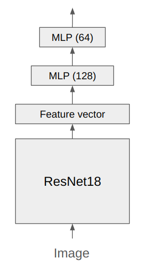

```python
class ImageEncoder(nn.Module):
    # TODO 18: implement the image encoder according to the above figure
    def __init__(self):
        super(ImageEncoder, self).__init__()
        resnet18 = torchvision.models.resnet18(weights=None)
        self.conv = torch.nn.Sequential(*(list(resnet18.children())[:-1]))
        self.glob_pool = nn.AdaptiveAvgPool2d(1)
        self.relu = nn.ReLU()
        self.mlp1 = nn.Linear(512, 128)
        self.mlp2 = nn.Linear(128, 64)


    def extract_feature(self, x):
        output = self.conv(x)
        output = self.glob_pool(output)
        output = output.view(output.size(0), -1)
        output = self.mlp1(output)
        output = self.relu(output)
        output = self.mlp2(output)
        return output

    def forward(self, input1, input2, input3):
        output1 = self.extract_feature(input1)
        output2 = self.extract_feature(input2)
        output3 = self.extract_feature(input3)
        return output1, output2, output3
```

## 3.3 (TODO) InfoNCE loss

Information Noise Contrastive Estimation (InfoNCE) loss (ref: [blog](https://lilianweng.github.io/posts/2021-05-31-contrastive/), [paper](https://arxiv.org/pdf/1807.03748v2.pdf)) is a self-supervised training objective aiming to maximizes the agreement between positive samples and minimizes the agreement between negative samples in the learned representation space. Although primarily designed for self-supervised learning, it could also be used in supervised setting by utilizing information from the labeled data.

When under self-supervision, images are sampled in batches, each of which is then augmented using two different augmentation policies. The contrastive loss is subsequently computed to maximize the similarity of the images of the same origin before augmentation while minimizing the similarity of the ones with different origins. In supervised learning, the objective maximizes the similarity of the images with the same identity (class) instead of origin. **In this part, we will train the InfoNCE loss under the supervised setting.**

To put it simply, the InfoNCE loss revolves around three types of images:

1. Anchor image: an initial image
2. Positive images: the sampled images with the same identity as the anchor image
3. Negative images: the sampled images whose identity differs from that of the anchor image

The objective is to maximize the cosine similarity between groups 1 and 2 while pushing groups 1 and 3 away. Thus, the InfoNCE maximizes the following objective:

Notation

- $B$ = batch size
- $P$ = the number of positive images per anchor
- $i$ = index of the anchor feature vector
- $P(i)$ = the sampled positive feature vectors
- $N(i)$ = the sampled negative feature vectors
- $cos(f_i, f_p)$ = cosine similarity between $f_i$ and $f_p$
- $f_i$ = anchor feature vector
- $f_p$ = positive feature vector
- $f_n$ = negative feature vector
- $\tau$ = temperature (a scaling factor for increasing/reducing the magnitude of logits)

**Hint** use `nn.CrossEntropy` to compute the exponential part

```python
class InfoNCELoss(nn.Module):
    # TODO 19: implement the InfoNCE loss
    def __init__(self, device, temperature):
        super(InfoNCELoss, self).__init__()
        self.device = device
        self.temperature = temperature

    def forward(self, anchor_feat, pos_feats, neg_feats):
        batch_size = anchor_feat.size(0)
        pos_size = pos_feats.size(0) // batch_size
        neg_size = neg_feats.size(0) // batch_size

        anchor_feat = anchor_feat.view(batch_size, 1, -1)  # [B, 1, D]
        pos_feats = pos_feats.view(batch_size, pos_size, -1)  # [B, P, D]
        neg_feats = neg_feats.view(batch_size, neg_size, -1)  # [B, N, D]

        cos_sim = nn.CosineSimilarity(dim=-1)

        total_loss = 0.0 # คำนวณ cross entropy loss ระหว่าง logits และ labels
        for p in range(pos_size):
            # anchor vs this one positive: [B, 1]
            pos_score = cos_sim(anchor_feat.squeeze(1), pos_feats[:, p, :]).unsqueeze(1)

            # anchor vs all negatives: [B, N]
            neg_scores = cos_sim(
                anchor_feat.expand(-1, neg_size, -1).reshape(batch_size * neg_size, -1),
                neg_feats.reshape(batch_size * neg_size, -1)
            ).view(batch_size, neg_size)

            # logits: [B, 1+N], label=0 means "column 0 is the positive"
            logits = torch.cat([pos_score, neg_scores], dim=1) / self.temperature
            labels = torch.zeros(batch_size, dtype=torch.long, device=self.device)

            total_loss += nn.CrossEntropyLoss()(logits, labels)
        return total_loss / pos_size
```

## 3.4 (TODO) Initializing model, criterions, optimizers, hyparameters and scheduler

```python
temperature = 0.2

infonce_model = ImageEncoder()
device = "cuda" if torch.cuda.is_available() else "cpu"
train_infonce_criterion = InfoNCELoss(device, temperature)
val_infonce_criterion = InfoNCELoss(device, temperature)

infonce_optimizer = optim.Adam(infonce_model.parameters(), lr=5e-4)
infonce_scheduler = optim.lr_scheduler.ReduceLROnPlateau(
    infonce_optimizer, "min", patience=4, factor=0.1, min_lr=1e-8
)
```

## 3.5 (TODO) Training loop

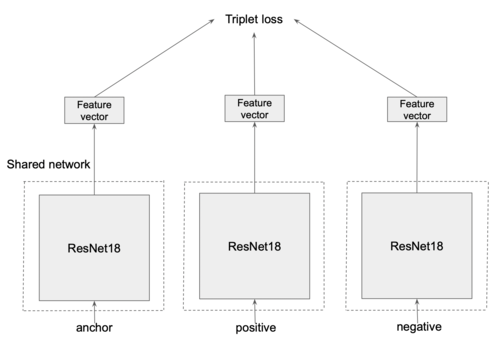

The training procedure of a infonce network consists of the following steps:

1. Foward pass `anchor_img`
2. Foward pass `pos_imgs`
3. Foward pass `neg_img`
4. Calculate all pairs cosine similarities between `anchor_img` and `pos_imgs`.
5. Calculate all pairs cosine similarities between `anchor_img` and `neg_imgs`.
6. Compute InfoNCE loss and take an average over them
7. Use the loss in step 6 to update the model
8. Repeat step 1-8 till converged

TODO 20: move training data to GPU memory, extract anchor, positive, negative features from images, and then use them to compute InfoNCE loss

TODO 21: set zero gradients

TODO 22 : back propagate at infonce network and step the optimizer

TODO 23: move validation data to GPU memory, extract anchor, positive, negative features from images, and then use them to compute InfoNCE loss

```python
num_epochs = 20
device = "cuda" if torch.cuda.is_available() else "cpu"

os.makedirs("weights", exist_ok=True)
best_weights_path = "weights/best_infonce_weights.pth"
infonce_model.to(device)
min_val_loss = float("inf")

train_losses = []
val_losses = []

for epoch in tqdm(range(num_epochs)):
    infonce_model.train()
    total_train_loss = 0
    for anchor_img, pos_imgs, neg_imgs, anchor_label, pos_labels, neg_labels in tqdm(
        train_infonce_dataloader
    ):

        # TODO 20: feed data to the infonce model and compute infonce loss
        anchor_img, pos_imgs, neg_imgs = (
            anchor_img.to(device),
            pos_imgs.to(device),
            neg_imgs.to(device),
        )
        pos_imgs_reshaped = pos_imgs.view(-1, *pos_imgs.size()[2:])
        neg_imgs_reshaped = neg_imgs.view(-1, *neg_imgs.size()[2:])

        anchor_feat, pos_feats, neg_feats = infonce_model(
            anchor_img, pos_imgs_reshaped, neg_imgs_reshaped
        )
        train_loss = train_infonce_criterion(anchor_feat, pos_feats, neg_feats)
        total_train_loss += train_loss.item()

        # TODO 21: set zero gradients
        infonce_optimizer.zero_grad()

        # TODO 22 : back propagate at infonce network and step the optimizer
        train_loss.backward()
        infonce_optimizer.step()
    current_train_loss = total_train_loss / len(train_infonce_dataloader)
    train_losses.append(current_train_loss)

    total_val_loss = 0
    infonce_model.eval()

    for val_anchor_img, val_pos_imgs, val_neg_imgs, _, _, _ in val_infonce_dataloader:
        # TODO 23: feed data to the infonce model and compute infonce loss
        val_anchor_img, val_pos_imgs, val_neg_imgs = (
            val_anchor_img.to(device),
            val_pos_imgs.to(device),
            val_neg_imgs.to(device),
        )

        with torch.no_grad():
            reshaped_val_pos_imgs = val_pos_imgs.view(-1, *val_pos_imgs.size()[2:])
            reshaped_val_neg_imgs = val_neg_imgs.view(-1, *val_neg_imgs.size()[2:])
            val_anchor_feat, val_pos_feats, val_neg_feats = infonce_model(val_anchor_img, reshaped_val_pos_imgs, reshaped_val_neg_imgs)
            val_loss = val_infonce_criterion(val_anchor_feat, val_pos_feats, val_neg_feats)
        total_val_loss += val_loss.item()
    current_val_loss = total_val_loss / len(val_infonce_dataloader)
    val_losses.append(current_val_loss)

    if current_val_loss < min_val_loss:
        min_val_loss = current_val_loss
        torch.save(infonce_model.state_dict(), best_weights_path)
    print(
        f"Epoch {epoch+1} "
        f"- Train loss = {current_train_loss:.4f} "
        f"- Val loss = {current_val_loss:.4f} "
        f"- best min_val_loss = {min_val_loss:.4f} "
        f'- lr = {infonce_optimizer.param_groups[0]["lr"]:.8f}'
    )
    infonce_scheduler.step(current_val_loss)
```

```
Epoch 1 - Train loss = 2.0413 - Val loss = 1.9282 - best min_val_loss = 1.9282 - lr = 0.00050000
```

```
Epoch 2 - Train loss = 1.9493 - Val loss = 1.9090 - best min_val_loss = 1.9090 - lr = 0.00050000
```

```
Epoch 3 - Train loss = 1.8124 - Val loss = 1.6849 - best min_val_loss = 1.6849 - lr = 0.00050000
```

```
Epoch 4 - Train loss = 1.6658 - Val loss = 1.4242 - best min_val_loss = 1.4242 - lr = 0.00050000
```

```
Epoch 5 - Train loss = 1.5451 - Val loss = 1.4737 - best min_val_loss = 1.4242 - lr = 0.00050000
```

```
Epoch 6 - Train loss = 1.4387 - Val loss = 1.3132 - best min_val_loss = 1.3132 - lr = 0.00050000
```

```
Epoch 7 - Train loss = 1.3629 - Val loss = 1.3351 - best min_val_loss = 1.3132 - lr = 0.00050000
```

```
Epoch 8 - Train loss = 1.2573 - Val loss = 1.2686 - best min_val_loss = 1.2686 - lr = 0.00050000
```

```
Epoch 9 - Train loss = 1.1830 - Val loss = 1.3474 - best min_val_loss = 1.2686 - lr = 0.00050000
```

```
Epoch 10 - Train loss = 1.0779 - Val loss = 1.3571 - best min_val_loss = 1.2686 - lr = 0.00050000
```

```
Epoch 11 - Train loss = 1.0073 - Val loss = 1.2837 - best min_val_loss = 1.2686 - lr = 0.00050000
```

```
Epoch 12 - Train loss = 0.9396 - Val loss = 1.3082 - best min_val_loss = 1.2686 - lr = 0.00050000
```

```
Epoch 13 - Train loss = 0.8424 - Val loss = 1.3180 - best min_val_loss = 1.2686 - lr = 0.00050000
```

```
Epoch 14 - Train loss = 0.6840 - Val loss = 1.3302 - best min_val_loss = 1.2686 - lr = 0.00005000
```

```
Epoch 15 - Train loss = 0.5847 - Val loss = 1.3380 - best min_val_loss = 1.2686 - lr = 0.00005000
```

```
Epoch 16 - Train loss = 0.5363 - Val loss = 1.2679 - best min_val_loss = 1.2679 - lr = 0.00005000
```

```
Epoch 17 - Train loss = 0.5109 - Val loss = 1.3527 - best min_val_loss = 1.2679 - lr = 0.00005000
```

```
Epoch 18 - Train loss = 0.4808 - Val loss = 1.3047 - best min_val_loss = 1.2679 - lr = 0.00005000
```

```
Epoch 19 - Train loss = 0.4664 - Val loss = 1.2518 - best min_val_loss = 1.2518 - lr = 0.00005000
```

```
Epoch 20 - Train loss = 0.4264 - Val loss = 1.2403 - best min_val_loss = 1.2403 - lr = 0.00005000
```

## 3.6 Visualization

The visualization below displays an anchor, positive, and negative image and their respective similarity.

```
Clipping input data to the valid range for imshow with RGB data ([0..1] for floats or [0..255] for integers). Got range [0.0..1.1742941].
```

[figure not shown]

```
Clipping input data to the valid range for imshow with RGB data ([0..1] for floats or [0..255] for integers). Got range [0.0..1.1742941].
```

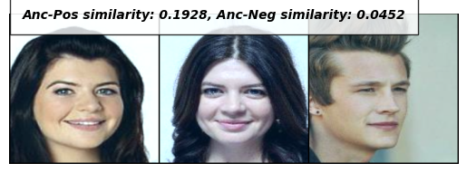

```
Clipping input data to the valid range for imshow with RGB data ([0..1] for floats or [0..255] for integers). Got range [0.0..1.1452472].
```

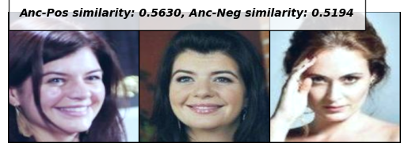

```
Clipping input data to the valid range for imshow with RGB data ([0..1] for floats or [0..255] for integers). Got range [0.0..1.1659949].
```

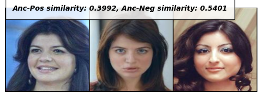

```
Clipping input data to the valid range for imshow with RGB data ([0..1] for floats or [0..255] for integers). Got range [0.0..1.1120508].
```

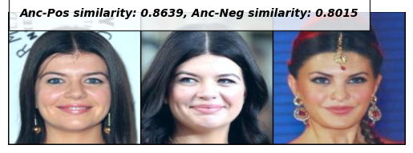

```
Clipping input data to the valid range for imshow with RGB data ([0..1] for floats or [0..255] for integers). Got range [0.0..1.1742941].
```

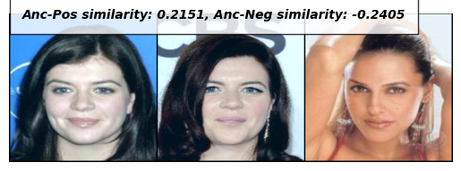

```
Clipping input data to the valid range for imshow with RGB data ([0..1] for floats or [0..255] for integers). Got range [0.0..1.1701446].
```

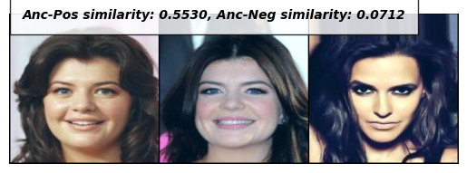

```
Clipping input data to the valid range for imshow with RGB data ([0..1] for floats or [0..255] for integers). Got range [0.0..1.1659949].
```

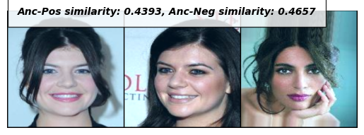

```
Clipping input data to the valid range for imshow with RGB data ([0..1] for floats or [0..255] for integers). Got range [0.0..1.1162004].
```

[figure not shown]

```
Clipping input data to the valid range for imshow with RGB data ([0..1] for floats or [0..255] for integers). Got range [0.0..1.1659949].
```

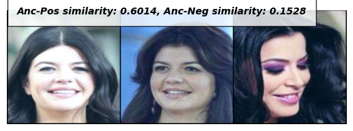

```
Clipping input data to the valid range for imshow with RGB data ([0..1] for floats or [0..255] for integers). Got range [0.0..1.1203499].
```

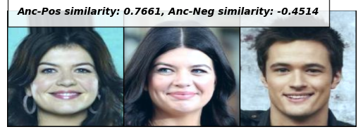

```
Clipping input data to the valid range for imshow with RGB data ([0..1] for floats or [0..255] for integers). Got range [0.0..1.1742941].
```

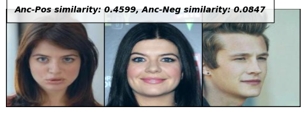

```
Clipping input data to the valid range for imshow with RGB data ([0..1] for floats or [0..255] for integers). Got range [0.0..1.1742941].
```

[4 more figures not shown]

```python
# Showing images
def imshow(img, text=None):
    npimg = img.numpy()
    plt.axis("off")
    if text:
        plt.text(
            20,
            8,
            text,
            style="italic",
            fontweight="bold",
            bbox={"facecolor": "white", "alpha": 0.8, "pad": 10},
        )

    plt.imshow(np.transpose(npimg, (1, 2, 0)))
    plt.show()


best_weights_path = "weights/best_infonce_weights.pth"
infonce_model.to(device)
infonce_model.load_state_dict(torch.load(best_weights_path))
infonce_model.eval()

test_anchor_imgs, batch_test_pos_imgs, batch_test_neg_imgs, test_anchor_ids, _, _ = (
    next(iter(test_infonce_dataloader))
)

test_pos_imgs = batch_test_pos_imgs[:, 0, :, :]
test_neg_imgs = batch_test_neg_imgs[:, 0, :, :]

test_anchor_imgs, test_pos_imgs, test_neg_imgs = (
    test_anchor_imgs.to(device),
    test_pos_imgs.to(device),
    test_neg_imgs.to(device),
)
with torch.no_grad():
    test_anchor_feats = infonce_model.extract_feature(test_anchor_imgs)
    test_pos_feats = infonce_model.extract_feature(test_pos_imgs)
    test_neg_feats = infonce_model.extract_feature(test_neg_imgs)


class UnNormalize(object):
    def __init__(self, mean, std):
        self.mean = mean
        self.std = std

    def __call__(self, tensor):
        """
        Args:
            tensor (Tensor): Tensor image of size (C, H, W) to be normalized.
        Returns:
            Tensor: Normalized image.
        """
        for t, m, s in zip(tensor, self.mean, self.std):
            t.mul_(s).add_(m)
            # The normalize code -> t.sub_(m).div_(s)
        return tensor


unnormalizer = UnNormalize(mean=[0.5319, 0.4399, 0.3929], std=[0.3076, 0.2898, 0.2907])

zip_test_data = zip(
    test_anchor_feats,
    test_pos_feats,
    test_neg_feats,
    test_anchor_imgs,
    test_pos_imgs,
    test_neg_imgs,
)
for (
    test_anchor_feat,
    test_pos_feat,
    test_neg_feat,
    test_anchor_img,
    test_pos_img,
    test_neg_img,
) in zip_test_data:
    test_anchor_img = unnormalizer(test_anchor_img.detach().cpu().unsqueeze(0))
    test_pos_img = unnormalizer(test_pos_img.detach().cpu().unsqueeze(0))
    test_neg_img = unnormalizer(test_neg_img.detach().cpu().unsqueeze(0))
    concatenated = torch.cat((test_anchor_img, test_pos_img, test_neg_img), 0)
    anc_pos_similarity = F.cosine_similarity(
        test_anchor_feat.unsqueeze(0), test_pos_feat.unsqueeze(0)
    )
    anc_neg_similarity = F.cosine_similarity(
        test_anchor_feat.unsqueeze(0), test_neg_feat.unsqueeze(0)
    )
    imshow(
        torchvision.utils.make_grid(concatenated),
        f"Anc-Pos similarity: {anc_pos_similarity.item():.4f}, Anc-Neg similarity: {anc_neg_similarity.item():.4f}",
    )
```

## 3.7 Plot loss history

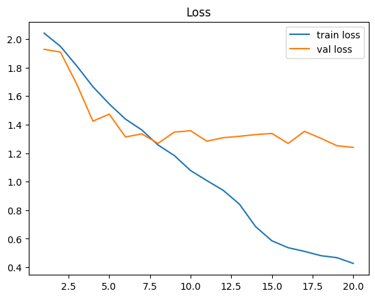

```python
import matplotlib.pyplot as plt

plt.plot(np.arange(1, len(train_losses) + 1), train_losses, label="train loss")
plt.plot(np.arange(1, len(val_losses) + 1), val_losses, label="val loss")
plt.legend()
plt.title("Loss")
plt.show()
```

## 3.8 (TODO) Plot t-SNE

This section is similar to section 1.8

**Instructions**

TODO 24: Extract the feature vectors of the test set and store them as

`embeddings`: torch.FloatTensor = feature vectors of all images in the test set

`identities`: list or torch.Tensor or np.array = identities of all images in the test set

**Hint**  
Use `FaceDataset` that is imported at `Common Dataset` section

**WARNING!!** Don't forget load its best weights and change to eval mode first

```python
test_batch_size = 32

# TODO 24: Extract the feature vectors of the test set and store them as
# `embeddings`: torch.FloatTensor = feature vectors of all images in the test set
# `identities`: list or torch.Tensor or np.array = identities of all images in the test set
# Hint      => Use `FaceDataset` that is imported at `Common Dataset` section
# WARNING!! => Don't forget load its best weights and change to eval mode first
test_dataset = FaceDataset(root_dir="large_prepared_data/test", transform=val_transform)
test_loader = DataLoader(test_dataset, batch_size=test_batch_size)
infonce_model.load_state_dict(torch.load(best_weights_path, map_location=device))
infonce_model.eval()
embeddings = []
identities = []
for transformed_img, identity, _ in tqdm(test_loader):
    transformed_img = transformed_img.to(device)
    with torch.no_grad():
        feat = infonce_model.extract_feature(transformed_img)
    embeddings.append(feat.cpu())
    if torch.is_tensor(identity):
        identities.append(identity.cpu())
    else:
        identities.extend(identity)
embeddings = torch.cat(embeddings)
if torch.is_tensor(identities[0]):
    identities = torch.cat(identities)
else:
    identities = np.array(identities)
```

```python
import time
from sklearn.manifold import TSNE

time_start = time.time()
tsne = TSNE(n_components=2, verbose=1, perplexity=30, max_iter=3000)
tsne_result = tsne.fit_transform(embeddings)
print("t-SNE done! Time elapsed: {} seconds".format(time.time() - time_start))
```

```
[t-SNE] Computing 91 nearest neighbors...
[t-SNE] Indexed 301 samples in 0.000s...
[t-SNE] Computed neighbors for 301 samples in 0.092s...
[t-SNE] Computed conditional probabilities for sample 301 / 301
[t-SNE] Mean sigma: 1.358665
[t-SNE] KL divergence after 250 iterations with early exaggeration: 54.221828
[t-SNE] KL divergence after 1600 iterations: 0.489774
t-SNE done! Time elapsed: 0.7882490158081055 seconds
```

```python
import plotly.express as px

label = []
idx = 0
id2label = dict()
for identity in identities:
    identity = int(identity)
    if identity not in id2label:
        id2label[identity] = idx
        idx += 1
    label.append(id2label[identity])

df_subset = pd.DataFrame({"label": label})

df_subset["tsne-2d-one"] = tsne_result[:, 0]
df_subset["tsne-2d-two"] = tsne_result[:, 1]

fig = px.scatter(
    df_subset, x="tsne-2d-one", y="tsne-2d-two", color="label", height=1000, width=1000
)
fig.update_layout(margin=dict(l=0, r=0, b=0, t=0))
fig.show()
```

[output not shown]

```python
import time
from sklearn.manifold import TSNE

time_start = time.time()
tsne = TSNE(n_components=3, verbose=1, perplexity=30, max_iter=3000)
tsne_result = tsne.fit_transform(embeddings)
print("t-SNE done! Time elapsed: {} seconds".format(time.time() - time_start))
```

```
[t-SNE] Computing 91 nearest neighbors...
[t-SNE] Indexed 301 samples in 0.000s...
[t-SNE] Computed neighbors for 301 samples in 0.005s...
[t-SNE] Computed conditional probabilities for sample 301 / 301
[t-SNE] Mean sigma: 1.358665
[t-SNE] KL divergence after 250 iterations with early exaggeration: 54.233986
[t-SNE] KL divergence after 700 iterations: 0.381459
t-SNE done! Time elapsed: 0.4764270782470703 seconds
```

```python
import plotly.express as px

label = []
idx = 0
id2label = dict()
for identity in identities:
    identity = int(identity)
    if identity not in id2label:
        id2label[identity] = idx
        idx += 1
    label.append(id2label[identity])

df_subset = pd.DataFrame({"label": label})

df_subset["tsne-3d-one"] = tsne_result[:, 0]
df_subset["tsne-3d-two"] = tsne_result[:, 1]
df_subset["tsne-3d-three"] = tsne_result[:, 2]

fig = px.scatter_3d(
    df_subset, x="tsne-3d-one", y="tsne-3d-two", z="tsne-3d-three", color="label"
)
fig.update_layout(margin=dict(l=0, r=0, b=0, t=0))
fig.show()
```

[output not shown]

## 3.9 (TODO) Please analyze and compare between the t-SNE of triplet network the t-SNE of InfoNCE network. Why are those t-SNEs not in the same way?

TODO 25: Answer the above question

**Hint** The reason is about our dataset

Answer: The InfoNCE network have better global cluster structure. Because trilet is focus only 1 negative at a time but InfoNCE softmax(pos) over all N negatives at once.

# Part 4 : Face verification evaluation

In HW3, we use the ROC curve to measure the performance of the face verification task. Similarly, we will use this metric to measure the performance of our NN.

TODO 26: Use the Siamese network, network trained using triplet loss, and network trained using InfoNCE loss to extract the image features from the test set.

```python
img_size = 224
val_transform = transforms.Compose(
    [
        transforms.Resize((256, 256)),
        transforms.CenterCrop(img_size),
        transforms.ToTensor(),
        transforms.Normalize(
            mean=[0.5319, 0.4399, 0.3929], std=[0.3076, 0.2898, 0.2907]
        ),
    ]
)


test_siamese_dataset = SiameseDataset(
    root_dir="large_prepared_data/test", transform=val_transform
)
test_siamese_dataloader = DataLoader(
    test_siamese_dataset, batch_size=test_batch_size, shuffle=False, num_workers=2
)

siamese_embeddings1 = []
siamese_embeddings2 = []
triplet_embeddings1 = []
triplet_embeddings2 = []
infonce_embeddings1 = []
infonce_embeddings2 = []
labels = []

device = "cuda" if torch.cuda.is_available() else "cpu"

siamese_model.to(device)
triplet_model.to(device)
infonce_model.to(device)

siamese_model.load_state_dict(torch.load("weights/best_siamese_weights.pth"))
triplet_model.load_state_dict(torch.load("weights/best_triplet_weights.pth"))
infonce_model.load_state_dict(torch.load("weights/best_infonce_weights.pth"))

siamese_model.eval()
triplet_model.eval()
infonce_model.eval()

for batch_img1, batch_img2, batch_label in tqdm(test_siamese_dataloader):
    batch_img1, batch_img2, batch_label = (
        batch_img1.to(device),
        batch_img2.to(device),
        batch_label.to(device),
    )
    with torch.no_grad():
        # TODO 26: extract features with both siamese network, triplet network, infonce network
        # and keep embeddings in provided lists according to variable names
        siamese_embeddings1.append(siamese_model.extract_feature(batch_img1).cpu())
        siamese_embeddings2.append(siamese_model.extract_feature(batch_img2).cpu())
        triplet_embeddings1.append(triplet_model.extract_feature(batch_img1).cpu())
        triplet_embeddings2.append(triplet_model.extract_feature(batch_img2).cpu())
        infonce_embeddings1.append(infonce_model.extract_feature(batch_img1).cpu())
        infonce_embeddings2.append(infonce_model.extract_feature(batch_img2).cpu())

    labels.append(batch_label)

siamese_embeddings1 = torch.cat(siamese_embeddings1)
siamese_embeddings2 = torch.cat(siamese_embeddings2)
triplet_embeddings1 = torch.cat(triplet_embeddings1)
triplet_embeddings2 = torch.cat(triplet_embeddings2)
infonce_embeddings1 = torch.cat(infonce_embeddings1)
infonce_embeddings2 = torch.cat(infonce_embeddings2)
labels = torch.cat(labels)
```

TODO 27: Measure the similarity score between the two feature vectors with cosine similarity.

**HINT** You can use `nn.CosineSimilarity` (ref: https://pytorch.org/docs/stable/generated/torch.nn.CosineSimilarity.html).

```python
def compute_pairs_cosine_sim(input1, input2):
    # TODO 27: implement cosine similarity function that can compute multiple pairs at the same time
    return F.cosine_similarity(input1, input2)


siamese_scores = compute_pairs_cosine_sim(siamese_embeddings1, siamese_embeddings2)
triplet_scores = compute_pairs_cosine_sim(triplet_embeddings1, triplet_embeddings2)
infonce_scores = compute_pairs_cosine_sim(infonce_embeddings1, infonce_embeddings2)
```

TODO 28

Plot a ROC curve to compare the performance siamese, triplet, infonce networks. Which one is better and why?

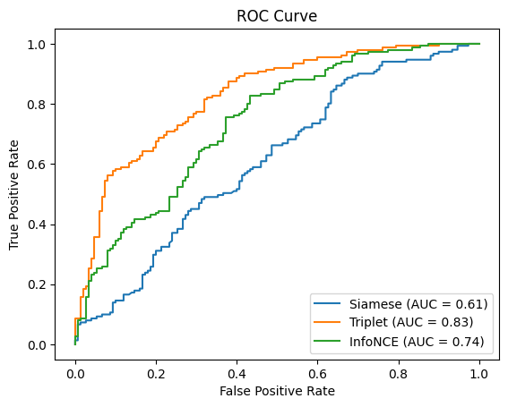

```python
import matplotlib.pyplot as plt

# TODO 28: calculate true positive rate and false positive rate
# and plot both the ROC curve of siamese network and the ROC curve of triplet network
# together with AUC score
from sklearn.metrics import roc_curve, roc_auc_score

siamese_fpr, siamese_tpr, _ = roc_curve(labels.cpu().numpy(), siamese_scores.cpu().numpy())
triplet_fpr, triplet_tpr, _ = roc_curve(labels.cpu().numpy(), triplet_scores.cpu().numpy())
infonce_fpr, infonce_tpr, _ = roc_curve(labels.cpu().numpy(), infonce_scores.cpu().numpy())

siamese_auc = roc_auc_score(labels.cpu().numpy(), siamese_scores.cpu().numpy())
triplet_auc = roc_auc_score(labels.cpu().numpy(), triplet_scores.cpu().numpy())
infonce_auc = roc_auc_score(labels.cpu().numpy(), infonce_scores.cpu().numpy())

plt.title("ROC Curve")
plt.plot(siamese_fpr, siamese_tpr, label=f'Siamese (AUC = {siamese_auc:.2f})')
plt.plot(triplet_fpr, triplet_tpr, label=f'Triplet (AUC = {triplet_auc:.2f})')
plt.plot(infonce_fpr, infonce_tpr, label=f'InfoNCE (AUC = {infonce_auc:.2f})')
plt.xlabel('False Positive Rate')
plt.ylabel('True Positive Rate')
plt.legend()
plt.show()
```

Ans: Among the three networks, the ranking by AUC is Triplet > InfoNCE > Siamese.

The Triplet network achieves the highest AUC because the task is essentially a binary classification problem — determining whether two images belong to the same identity or not. This is precisely what Triplet loss optimizes for: it enforces a clear margin between same-class and different-class pairs, making the decision boundary sharp and well-suited for AUC measurement.

InfoNCE ranks second. While it produces more globally well-separated clusters with uniform inter-class spacing, its objective is optimized for ranking the positive above all negatives simultaneously rather than drawing a crisp binary boundary. This global structure is powerful for retrieval tasks but translates slightly less directly into pairwise AUC.

Siamese ranks last because it only sees one positive-negative pair at a time with a fixed contrastive margin, giving it the weakest signal — it has neither the margin sharpness of Triplet nor the global pressure of InfoNCE.